# Supplementary Material- Calibration of NWheat simulation model

J. Mauricio Fernandes and Thiago Berton

2024-12-17

# 1 Introduction

This report aims to demonstrate, using R programming, all the steps of the analysis of the *Year, Sowing Date and Variety* relationship, in Dinajpur, from data preparation to presentation of the results.

## 1.1 Packages

```r
library(tidyverse)
library(gsheet)
library(metan)
library(summarytools)
```

```r
library(ggplot2)
library(ggside)
library(tidyquant)
library(plyr)
```

## 1.2 Importing data

The data was organized in the long format where each column is a variable and each observation is placed in a row. The code to import the data is:

```r
## Load Data revised dataset (Received on September 21st, 2022)

dt<-gsheet2tbl("https://docs.google.com/spreadsheets/d/1USmV2yikAB1HYWVo8G65f8nEnKeYoEBR/edit?usp=sharing&ouid=118404758727192723928&rtpof=true&sd=true")


# Display the first few rows of the dataset
head(dt)
```

```
## # A tibble: 6 × 33
##   Location year   REP   sowing variety  CHTD   EAD   GPD   GAD  GYAM  HIAM  GWGD
##   <chr>    <chr>  <chr>  <dbl> <chr>   <dbl> <dbl> <dbl> <dbl> <dbl> <dbl> <dbl>
## 1 Dinajpur 2017-… I          1 BARI G…     1   260    53 13806  4890    44    47
## 2 Dinajpur 2017-… I          1 BARI G…     1   323    45 14600  4831    46    47
## 3 Dinajpur 2017-… I          1 BARI G…     1   337    45 15030  4649    40    47
## 4 Dinajpur 2017-… I          1 BARI G…     1   331    45 14994  4066    30    50
## 5 Dinajpur 2017-… I          1 BARI G…     1   352    40 14080  4926    49    46
## 6 Dinajpur 2017-… I          1 BARI G…     1   275    49 13475  5069    43    47
## # ℹ 21 more variables: EDAP <dbl>, ADAP <dbl>, MDAP <dbl>, CWAA <dbl>,
## #   CWAM <dbl>, WB <dbl>, Lodging <dbl>, edapTmax <dbl>, edapTmin <dbl>,
## #   edapTmean <dbl>, edapRHmax <dbl>, edapRHmin <dbl>, edapRHmean <dbl>,
## #   mdapTmax <dbl>, mdapTmin <dbl>, mdapTmean <dbl>, mdapRHmax <dbl>,
## #   mdapRHmin <dbl>, mdapRHmean <dbl>, edapRain <dbl>, mdapRain <dbl>
```

```r
# Summary of the dataset
summary(dt)
```

```
##    Location             year               REP                sowing
##  Length:1485        Length:1485        Length:1485        Min.   :1
##  Class :character   Class :character   Class :character   1st Qu.:2
##  Mode  :character   Mode  :character   Mode  :character   Median :3
##                                                           Mean   :3
##                                                           3rd Qu.:4
##                                                           Max.   :5
##
##    variety               CHTD         EAD             GPD
##  Length:1485        Min.   :1    Min.   :190.0   Min.   :21.00
##  Class :character   1st Qu.:1    1st Qu.:274.0   1st Qu.:40.00
##  Mode  :character   Median :1    Median :301.0   Median :43.00
##                     Mean   :1    Mean   :301.9   Mean   :43.39
##                     3rd Qu.:1    3rd Qu.:327.0   3rd Qu.:46.00
##                     Max.   :1    Max.   :498.0   Max.   :65.00
##                     NA's   :21   NA's   :21      NA's   :105
##       GAD             GYAM           HIAM            GWGD            EDAP
##  Min.   : 6655   Min.   : 445   Min.   : 8.00   Min.   :11.00   Min.   :4.000
##  1st Qu.:11211   1st Qu.:2600   1st Qu.:28.00   1st Qu.:36.00   1st Qu.:5.000
##  Median :12842   Median :3536   Median :35.00   Median :42.00   Median :6.000
##  Mean   :13058   Mean   :3461   Mean   :33.25   Mean   :40.23   Mean   :5.941
##  3rd Qu.:14720   3rd Qu.:4265   3rd Qu.:39.00   3rd Qu.:46.00   3rd Qu.:7.000
##  Max.   :23940   Max.   :6365   Max.   :53.00   Max.   :67.00   Max.   :9.000
##  NA's   :105     NA's   :21     NA's   :105     NA's   :21      NA's   :21
##       ADAP            MDAP            CWAA           CWAM
##  Min.   :48.00   Min.   : 80.0   Min.   :1905   Min.   : 6000
##  1st Qu.:63.00   1st Qu.: 97.0   1st Qu.:5621   1st Qu.: 9710
##  Median :66.00   Median :101.0   Median :5828   Median :10368
##  Mean   :65.38   Mean   :100.4   Mean   :5859   Mean   :10454
##  3rd Qu.:69.00   3rd Qu.:105.0   3rd Qu.:6050   3rd Qu.:11150
##  Max.   :85.00   Max.   :114.0   Max.   :9920   Max.   :18533
##  NA's   :21      NA's   :21      NA's   :105    NA's   :105
##        WB            Lodging          edapTmax        edapTmin
##  Min.   : 0.000   Min.   : 0.000   Min.   :18.00   Min.   : 2.00
##  1st Qu.: 0.000   1st Qu.: 0.000   1st Qu.:25.50   1st Qu.:10.00
##  Median : 0.000   Median : 0.000   Median :26.90   Median :11.70
##  Mean   : 8.016   Mean   : 3.685   Mean   :26.89   Mean   :11.58
##  3rd Qu.: 0.000   3rd Qu.: 0.000   3rd Qu.:28.60   3rd Qu.:13.60
##  Max.   :97.000   Max.   :90.000   Max.   :32.00   Max.   :19.00
##  NA's   :21       NA's   :21       NA's   :105     NA's   :105
```

[output cut: 9 more lines]

```
##  Min.   :29.7   Min.   : 1.00   Min.   :17.90   Min.   : 96.00
##  1st Qu.:33.7   1st Qu.:10.33   1st Qu.:21.94   1st Qu.: 98.00
##  Median :35.4   Median :13.00   Median :23.87   Median : 98.00
##  Mean   :35.2   Mean   :11.94   Mean   :23.62   Mean   : 98.37
##  3rd Qu.:36.4   3rd Qu.:14.90   3rd Qu.:25.21   3rd Qu.: 99.00
##  Max.   :38.5   Max.   :21.00   Max.   :29.31   Max.   :100.00
##  NA's   :105    NA's   :105     NA's   :105     NA's   :105
##    mdapRHmin       mdapRHmean       edapRain      mdapRain
##  Min.   : 0.00   Min.   :64.02   Min.   :0     Min.   :6
##  1st Qu.:15.00   1st Qu.:68.95   1st Qu.:0     1st Qu.:6
##  Median :18.00   Median :70.94   Median :0     Median :6
##  Mean   :16.61   Mean   :71.09   Mean   :0     Mean   :6
##  3rd Qu.:21.00   3rd Qu.:72.71   3rd Qu.:0     3rd Qu.:6
##  Max.   :30.00   Max.   :79.32   Max.   :0     Max.   :6
##  NA's   :105     NA's   :105     NA's   :105   NA's   :105
```

```r
# Working directory

setwd("~/Dropbox/Frontiers/supplemenMaterial")
```

## 1.3 Experiment details

The experiments aiming for calibration and evaluation of the DSSAT-NWheat simulation model consisted of four varieties (Table 1). The experiments were fully irrigated to maintain optimum soil moisture near field capacity. The land of the experimental fields was plowed with a two-wheel tractor, and it was exposed to sunshine for seven days before the subsequent plowing. After that, the land was deep-plowed and cross-plowed to obtain good tilth, which allows for better crop yield. All weeds and stubble were removed from the experimental field. The soil was treated with Furadan 5G, which contains Carbofuran, at 8 kg ha-1 to protect the young plants from insect attack. Recommended levels of mineral fertilizers for the region were applied: 100-27-40-20-1 kg ha-1 of N (nitrogen)-P (phosphorus)-K (potassium)-S (sulphur)-B (boron). Two-thirds of N and a full amount of the other fertilizers were applied immediately after final land preparation. The remaining N fertilizer was applied before the first irrigation (17-21 days after sowing). Before sowing, seeds were treated with Provax-200 WP, a fungicide recommended for controlling soil-borne fungi at the seedling stage. Seeds were sown in line continuously at 120 kg ha-1 for all varieties except BARI Gom 33 (140 kg ha-1) at a depth of 4-5 cm by making specific narrow furrows with an iron rod. After sowing, seeds were covered with soil and slightly pressed by hand. Seeds were repeatedly sown according to treatment dates using a 20 cm row-to-row distance. Three irrigations were applied during the whole growth period, where first irrigation was applied at 17-21 DAS (at crown root initiation), Second and third irrigations were applied at booting (50-55 DAS) and grain-filling (70-75 DAS) stages. A 2.5 cm water flow was applied in a 6 m2 plot during the first, second, and third irrigation. The experiment was conducted in a split-plot design with three replications. Main plots were assigned with five Sowing dates (i.e., Nov. 25, Dec. 05, Dec. 15, Dec. 25, and January 04), and subplots were with four wheat varieties (BARI Gom 26, BARI Gom 30, BARI Gom 32, BARI Gom 33). Plot size was 3x2 m (6 m2 for each subplot) (3m long 10 rows) in all three locations and years.

[figure not shown]

Map of Bangladesh highlighting the experiment locations (blue circles) and available automated weather stations.

A brief description of the four varieties used in the experiments

| Name_of_the_variety | Pedigree | Year_of_Release |
| --- | --- | --- |
| Bari Gom 26 | ICTAL123/3/RAWAL87//VEE/HD 2285BD(JO)9585-0JO-3JE-0JE-0JE-HRDI-RC5DI | 2010 |
| Bari Gom 30 | BAW677(PASTOR/3/VEE#5//DOVE/BUC )/BijoyBD(JA)1365S-0DI-15DI-3DI-HR12R3DI | 2014 |
| Bari Gom 32 | SHATABDI/GOURABBD(DI)1686S-0DI-1DI-0DI-0DI-3DI | 2017 |
| Bari Gom 33 | KACHU/SOLALACMSS09Y00580S-099Y-38M-0WGY-4B-0Y | 2017 |

## 1.4 Soil characteristics and weather data

Detailed soil characterization was conducted for each experimental location before planting. Soil excavations were dug in each site, and soil samples were taken from each layer. The collected samples were then analyzed for pH, Organic Carbon, Total Nitrogen, Phosphorus, exchangeable potassium (K), Sulfur, Calcium, Magnesium, Boro, Zinc, Iron, Manganese, Copper, Soil Moisture, Bulk Density, Hydraulic Conductivity, and Soil Texture. The Soil data tool (SBuild) present in DSSAT v. 4.8 was used to create the soil database, which was used for general simulation purposes. The data entered in this utility were the name of the country, name of the experimental site, site code, site coordinates, soil series, and classification. Measured soil characteristics taken from each profile were used to calculate the soil physical and chemical parameters needed to run the DSSAT- NWwheat model. A detailed description of the initial soil conditions in Dinajpur and Rajshahi is presented in Supplementary Material 1.

The observed weather variables used in this study include air temperature (C), relative humidity (%), and precipitation (mm) registered every 15 minutes. These weather variables were acquired from the Bangladesh Meteorological Department (BMD) and uploaded to a database. Solar radiation was retrieved from ERA5, a global atmospheric reanalysis dataset produced by the European Centre for Medium-Range Weather Forecasts (ECMWF).

## 1.5 Crop measurements

The evaluation of crop development was done by observing the phenology of the different wheat varieties and recording the time (days) it takes to attain each phenological phase. The recorded measurements were the grain number per plant, grain yield at maturity, harvest index at maturity, grain unit dry weight, emergence day after planting, anthesis day after planting, maturity days after planting, canopy weight at anthesis and canopy weight at maturity. All data were recorded from 1 meter long in five tagged rows in every plot. Yield and yield components measurements were taken at harvest maturity.

## 1.7 Goodness‑of‑ft and evaluation of predictions

Goodness-of-fit refers to how well a calibrated model matches the data used for calibration. Prediction accuracy, on the other hand, measures how effectively a calibrated model simulates outcomes in environments different from those in the calibration dataset. For both goodness-of-fit and out-of-sample prediction, we used three metrics to measure the agreements between simulated and observed values. The root mean squared error (RMSE) (Eq. 1), the d-statistic (Eq. 2), and a skill score (Eq. 3) referred to as model efficiency (E) (Wallach et al., 2021).

The Root Mean Squared Error (RMSE) is defined as:

$$RMSE = \sqrt{\frac{1}{n} \sum_{i=1}^n (y_i - \hat{y}_i)^2}$$
RMSE is a common metric used to evaluate the performance of a model. It is an absolute measure of fit, meaning it measures how close the predicted values are to the true values. The RMSE takes on the same unit of deviation, Predicted-Observed, and it is commonly used in both model calibration and evaluation processes (Loague and Green, 1991).

The Index of Agreement (d) is defined as:

$$d = 1 - \frac{\sum_{i=1}^n (y_i - \hat{y}_i)^2}{\sum_{i=1}^n (|y_i -
\bar{y}| + |\hat{y}_i - \bar{y}|)^2}$$
Model efficiency is a dimensionless measure, an E = 1 corresponds to a perfect match of modeled output with the observed data and E < 1 for any realistic simulation. EF < 0 if the model predictions are worse than simply using the observed mean replace the simulated value. To some extent, E ≥ 0 is a critical condition to conclude ‘‘goodness of match’’ between the simulated and the observed (Wilmont et al., 2012; Yang, et al., 2014).

The Model Efficiency (E) is defined as:

$$E = 1 - \frac{\sum_{i=1}^n (y_i - \hat{y}_i)^2}{\sum_{i=1}^n (y_i -
\bar{y})^2}$$

In equations above Pi and Oi are the ith the model predictions and the pairwise-matched observations that are judged to be reliable, respectively, and n is the number of measurements summed for all varieties and sowing dates.

## 1.9 Methods

Statistical Analysis The following code illustrates the statistical analyses performed in this study.

```r
head(dt)
```

```
## # A tibble: 6 × 33
##   Location year   REP   sowing variety  CHTD   EAD   GPD   GAD  GYAM  HIAM  GWGD
##   <chr>    <chr>  <chr>  <dbl> <chr>   <dbl> <dbl> <dbl> <dbl> <dbl> <dbl> <dbl>
## 1 Dinajpur 2017-… I          1 BARI G…     1   260    53 13806  4890    44    47
## 2 Dinajpur 2017-… I          1 BARI G…     1   323    45 14600  4831    46    47
## 3 Dinajpur 2017-… I          1 BARI G…     1   337    45 15030  4649    40    47
## 4 Dinajpur 2017-… I          1 BARI G…     1   331    45 14994  4066    30    50
## 5 Dinajpur 2017-… I          1 BARI G…     1   352    40 14080  4926    49    46
## 6 Dinajpur 2017-… I          1 BARI G…     1   275    49 13475  5069    43    47
## # ℹ 21 more variables: EDAP <dbl>, ADAP <dbl>, MDAP <dbl>, CWAA <dbl>,
## #   CWAM <dbl>, WB <dbl>, Lodging <dbl>, edapTmax <dbl>, edapTmin <dbl>,
## #   edapTmean <dbl>, edapRHmax <dbl>, edapRHmin <dbl>, edapRHmean <dbl>,
## #   mdapTmax <dbl>, mdapTmin <dbl>, mdapTmean <dbl>, mdapRHmax <dbl>,
## #   mdapRHmin <dbl>, mdapRHmean <dbl>, edapRain <dbl>, mdapRain <dbl>
```

```r
dt$sowing = as_factor(dt$sowing)
dt$year<-as_factor(dt$year)
dt$Location<-as_factor(dt$Location)
dt$variety<-as_factor(dt$variety)
dt$REP<-as_factor(dt$REP)



print(freq(dt$Location), method = 'render')
```

Frequencies

dt$Location

**Type**: Factor

| Location | Freq | Valid % | Valid % Cum. | Total % | Total % Cum. |
| --- | --- | --- | --- | --- | --- |
| Dinajpur | 495 | 33.33 | 33.33 | 33.33 | 33.33 |
| Jashore | 495 | 33.33 | 66.67 | 33.33 | 66.67 |
| Rajshahi | 495 | 33.33 | 100.00 | 33.33 | 100.00 |
| <NA> | 0 |  |  | 0.00 | 100.00 |
| Total | 1485 | 100.00 | 100.00 | 100.00 | 100.00 |

Generated by summarytools 1.0.1 ([R](https://www.r-project.org/) version 4.4.2)  
2024-12-17

```r
print(freq(dt$variety), method = 'render')
```

Frequencies

dt$variety

**Type**: Factor

| variety | Freq | Valid % | Valid % Cum. | Total % | Total % Cum. |
| --- | --- | --- | --- | --- | --- |
| BARI GOM 26 | 225 | 15.15 | 15.15 | 15.15 | 15.15 |
| BARI GOM 28 | 135 | 9.09 | 24.24 | 9.09 | 24.24 |
| BARI GOM 30 | 225 | 15.15 | 39.39 | 15.15 | 39.39 |
| BARI GOM 31 | 135 | 9.09 | 48.48 | 9.09 | 48.48 |
| BARI GOM 32 | 225 | 15.15 | 63.64 | 15.15 | 63.64 |
| BARI GOM 33 | 225 | 15.15 | 78.79 | 15.15 | 78.79 |
| WMRI GOM 01 | 135 | 9.09 | 87.88 | 9.09 | 87.88 |
| WMRI GOM 02 | 90 | 6.06 | 93.94 | 6.06 | 93.94 |
| WMRI GOM 03 | 90 | 6.06 | 100.00 | 6.06 | 100.00 |
| <NA> | 0 |  |  | 0.00 | 100.00 |
| Total | 1485 | 100.00 | 100.00 | 100.00 | 100.00 |

Generated by summarytools 1.0.1 ([R](https://www.r-project.org/) version 4.4.2)  
2024-12-17

```r
print(freq(dt$year), method = 'render')
```

Frequencies

dt$year

**Type**: Factor

| year | Freq | Valid % | Valid % Cum. | Total % | Total % Cum. |
| --- | --- | --- | --- | --- | --- |
| 2017-18 | 270 | 18.18 | 18.18 | 18.18 | 18.18 |
| 2018-19 | 270 | 18.18 | 36.36 | 18.18 | 36.36 |
| 2019-20 | 315 | 21.21 | 57.58 | 21.21 | 57.58 |
| 2020-21 | 315 | 21.21 | 78.79 | 21.21 | 78.79 |
| 2021-22 | 315 | 21.21 | 100.00 | 21.21 | 100.00 |
| <NA> | 0 |  |  | 0.00 | 100.00 |
| Total | 1485 | 100.00 | 100.00 | 100.00 | 100.00 |

Generated by summarytools 1.0.1 ([R](https://www.r-project.org/) version 4.4.2)  
2024-12-17

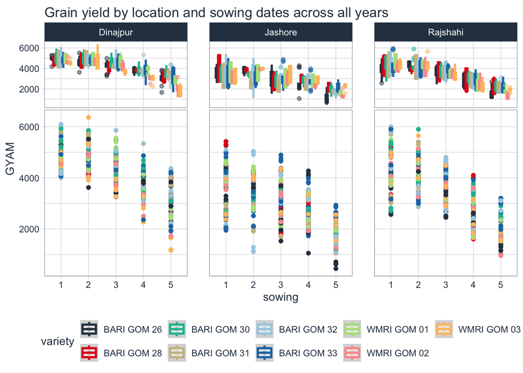

```r
ggplot(dt, aes(x = sowing, y = GYAM, color = variety)) +
  geom_point() +
  geom_smooth(aes(color = NULL)) +
  geom_xsideboxplot(
    alpha    = 0.5,
    size     = 1
  ) +
  scale_color_tq() +
  scale_fill_tq() +
  theme_tq() +
  facet_grid(cols = vars(Location), scales = "free_x") +
  labs(
    title = "Grain yield by location and sowing dates across all years"
  ) +
  theme(
    ggside.panel.scale.x = 0.4
  )
```

```
## Trait: HIAM
## Number of possible outliers: 4
## Line(s): 1094 1129 1164 1304
## Proportion: 0.3%
## Mean of the outliers: 8.75
## Maximum of the outliers: 11  | Line 1304
## Minimum of the outliers: 8  | Line 1094 1129 1164
## With outliers:    mean = 33.253 | CV = 24.546%
## Without outliers: mean = 33.324 | CV = 24.204%
```

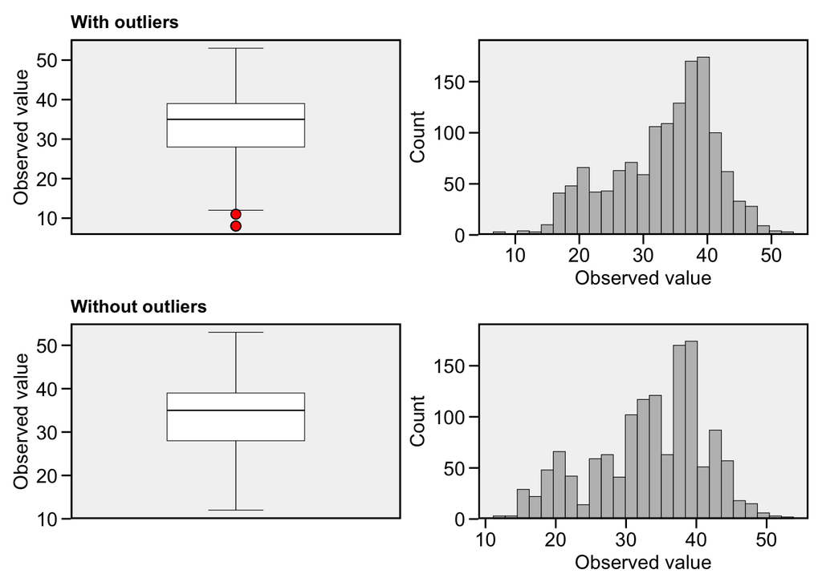

```r
find_outliers(dt, HIAM, plots = TRUE) #     Harvest index at maturity
```

[output not shown]

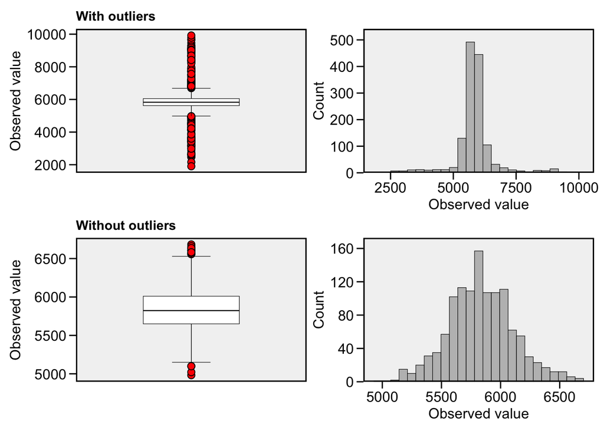

```r
find_outliers(dt, CWAA, plots = TRUE) #     Tops dry weight at anthesis
```

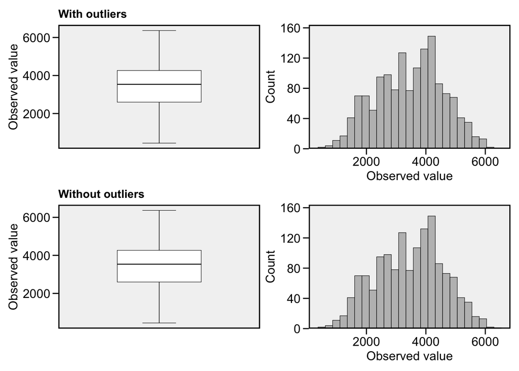

```
## No possible outlier identified.
```

```r
find_outliers(dt, GYAM, plots = TRUE) #     Grain yield at maturity
```

## 1.10 Visualization

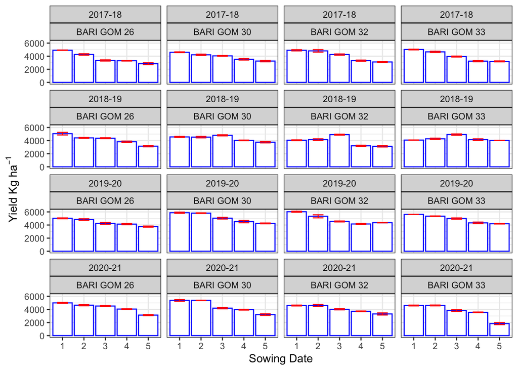

```r
# Filter the data based on the conditions.
# Wheat blast was present in the area of the Experimental Station
dt_l<-filter(dt, Location=="Dinajpur")
dt_v<-filter(dt_l,variety== "BARI GOM 26" | variety== "BARI GOM 30"
                                  | variety== "BARI GOM 32" |variety== "BARI GOM 33" )
dt_y<-filter(dt_v,year=="2017-18"|year=="2018-19"|year=="2019-20"|year=="2020-21")


# Yield
# Calculate the mean standard error for each combination of factors
yield <- ddply(dt_y, c("year", "variety", "sowing"), summarise,
                 N    = length(REP),
                 mean = mean(GYAM),
                 sd   = sd(GYAM),
                 se   = sd / sqrt(N))

ggplot(yield, aes(x=sowing, y=mean)) +
  geom_bar(stat="identity",color="blue", fill="white") +
  geom_errorbar(aes(ymin=mean-sd, ymax=mean+sd), width=.5,
                position=position_dodge(.9),color="red") +
  ylab(expression("Yield Kg ha"^-1)) +
  xlab("Sowing Date")+
  facet_wrap(~year+variety)+
  theme_bw()
```

```r
ggsave("yieldDinajpur.png", width = 20, height = 20, units = "cm")
```